# BioGSP: Spectral Graph Wavelet Transform for Spatial Data (New Workflow)

BioGSP Package

2025-09-29

# Introduction

BioGSP provides **Spectral Graph Wavelet Transform (SGWT)** analysis for spatial biological data. This package enables multi-scale analysis of spatial patterns using graph signal processing techniques.

**NEW in Version 2.0+**: Complete workflow restructure with object-oriented design!

## Key Capabilities

- **Object-oriented SGWT workflow** with clear separation of concerns
- **Multi-scale spatial analysis** using spectral graph wavelets
- **Flexible data input** with custom column naming
- **Energy-normalized similarity analysis** with comprehensive metrics
- **Multiple wavelet kernels** (Mexican Hat, Meyer, Heat)
- **Comprehensive visualization** tools
- **Detailed inverse transform results** (low-pass, band-pass approximations)

## New Workflow Overview

The new workflow consists of four main steps:

1. **`initSGWT()`**: Initialize SGWT object with data and parameters
2. **`runSpecGraph()`**: Build spectral graph structure
3. **`runSGWT()`**: Perform forward and inverse SGWT transforms
4. **`runSGCC()`**: Calculate energy-normalized weighted similarity

# Setup

```r
# Load required packages
library(ggplot2)
library(patchwork)
library(viridis)
library(Matrix)
library(igraph)
library(RANN)
library(RSpectra)

# Load BioGSP functions
source('../R/simulation.R')
source('../R/sgwt_core.R')
source('../R/sgwt_main.R')
source('../R/utilities.R')
source('../R/visualization.R')

# Set random seed for reproducibility
set.seed(123)
```

# New SGWT Workflow Demonstration

## Generate Example Pattern

```r
# Create a spatial pattern with concentric circles
demo_pattern <- simulate_multiscale(
  grid_size = 40,        # Moderate size for fast computation
  n_centers = 1,         # Single center pattern
  Ra_seq = 5,            # Inner circle radius
  Rb_seq = 10,           # Outer ring radius
  seed = 123
)[[1]]
```

```
## Generating 1 multiscale patterns...
##
##
## Multiscale simulation completed!
```

```r
# Display pattern structure
cat("Generated pattern dimensions:", nrow(demo_pattern), "x", ncol(demo_pattern), "\n")
```

```
## Generated pattern dimensions: 1600 x 4
```

```r
cat("Column names:", paste(colnames(demo_pattern), collapse = ", "), "\n")
```

```
## Column names: X, Y, signal_1, signal_2
```

```r
cat("Signals available:", sum(demo_pattern$signal_1), "inner pixels,", sum(demo_pattern$signal_2), "outer pixels\n")
```

```
## Signals available: 81 inner pixels, 628 outer pixels
```

## Visualize Input Pattern

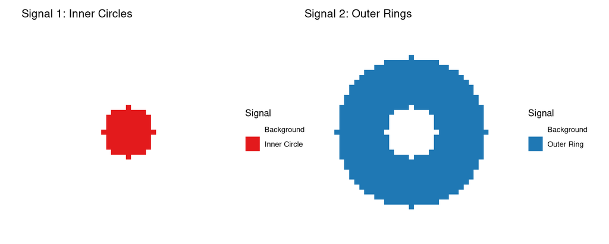

```r
# Create visualizations for both signals
p1 <- ggplot(demo_pattern, aes(X, Y, fill = factor(signal_1))) +
  geom_tile() +
  scale_fill_manual(values = c("0" = "white", "1" = "#e31a1c"),
                    name = "Signal", labels = c("Background", "Inner Circle")) +
  coord_fixed() + theme_void() + ggtitle("Signal 1: Inner Circles")

p2 <- ggplot(demo_pattern, aes(X, Y, fill = factor(signal_2))) +
  geom_tile() +
  scale_fill_manual(values = c("0" = "white", "1" = "#1f78b4"),
                    name = "Signal", labels = c("Background", "Outer Ring")) +
  coord_fixed() + theme_void() + ggtitle("Signal 2: Outer Rings")

print(p1 + p2)
```

## Step 1: Initialize SGWT Object

```r
# Initialize SGWT object with custom column names
SG <- initSGWT(
  data.in = demo_pattern,
  x_col = "X",           # Custom X coordinate column name
  y_col = "Y",           # Custom Y coordinate column name
  signals = c("signal_1", "signal_2"),  # Analyze both signals
  J = 4,                 # Number of wavelet scales
  scaling_factor = 2,    # Scale progression factor
  kernel_type = "heat"
)

# Display initialized object
print(SG)
```

```
## SGWT Object
## ===========
## Data:
##   Dimensions: 1600 x 4
##   Coordinates: X , Y
##   Signals: signal_1, signal_2
##
## Parameters:
##   k (neighbors): heat
##   J (scales): 4
##   Kernel type: heat
##   Laplacian type:
##
## Status:
##   Graph computed: FALSE
##   Forward computed: FALSE
##   Inverse computed: FALSE
```

## Step 2: Build Spectral Graph

```r
# Build spectral graph structure
SG <- runSpecGraph(SG, k = 12, laplacian_type = "normalized", length_eigenvalue = 100, verbose = TRUE)
```

```
## Building graph from spatial coordinates...
## Computing Laplacian and eigendecomposition...
## Auto-generated scales: 0.3761, 0.1881, 0.094, 0.047
## Graph construction completed.
```

```r
# Check updated object
cat("Graph construction completed!\n")
```

```
## Graph construction completed!
```

```r
cat("Adjacency matrix dimensions:", dim(SG$Graph$adjacency_matrix), "\n")
```

```
## Adjacency matrix dimensions: 1600 1600
```

```r
cat("Number of eigenvalues computed:", length(SG$Graph$eigenvalues), "\n")
```

```
## Number of eigenvalues computed: 100
```

## Visualize Fourier Modes (Eigenvectors)

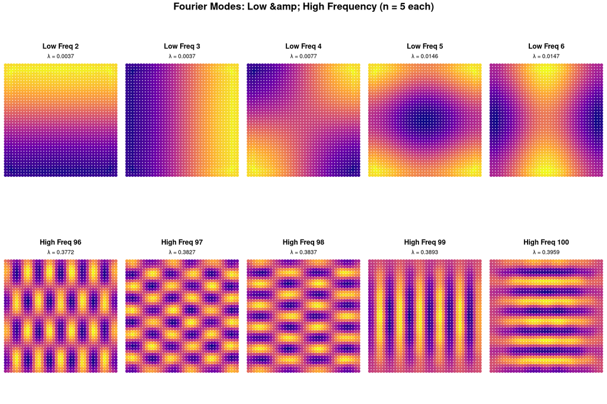

```r
# Visualize Fourier modes (eigenvectors) - 5 low and 5 high frequency modes
fourier_modes <- plot_FM(SG, mode_type = "both", n_modes = 5, ncol = 5)
```

```r
cat("Fourier Modes Visualization:\n")
```

```
## Fourier Modes Visualization:
```

```r
cat("- Low-frequency modes (2-6): Smooth spatial patterns, excluding DC component\n")
```

```
## - Low-frequency modes (2-6): Smooth spatial patterns, excluding DC component
```

```r
cat("- High-frequency modes (96-100): Fine-detailed spatial patterns\n")
```

```
## - High-frequency modes (96-100): Fine-detailed spatial patterns
```

```r
cat("- Each mode shows its eigenvalue (λ) indicating frequency content\n")
```

```
## - Each mode shows its eigenvalue (λ) indicating frequency content
```

## Step 3: Run SGWT Analysis

```r
# Perform SGWT forward and inverse transforms
SG <- runSGWT(SG, verbose = TRUE)
```

```
## Performing SGWT analysis for 2 signals...
## Using batch processing for efficiency...
## SGWT analysis completed.
```

```r
# Display final object with all results
print(SG)
```

```
## SGWT Object
## ===========
## Data:
##   Dimensions: 1600 x 4
##   Coordinates: X , Y
##   Signals: signal_1, signal_2
##
## Parameters:
##   k (neighbors): heat
##   J (scales): 4
##   Kernel type: heat
##   Laplacian type:
##   Scales: 0.3761, 0.1881, 0.094, 0.047
##
## Status:
##   Graph computed: TRUE
##   Forward computed: TRUE
##   Inverse computed: TRUE
##
## Reconstruction Errors:
##    signal_1 : 0.175508
##    signal_2 : 0.375262
```

## Visualize SGWT Decomposition

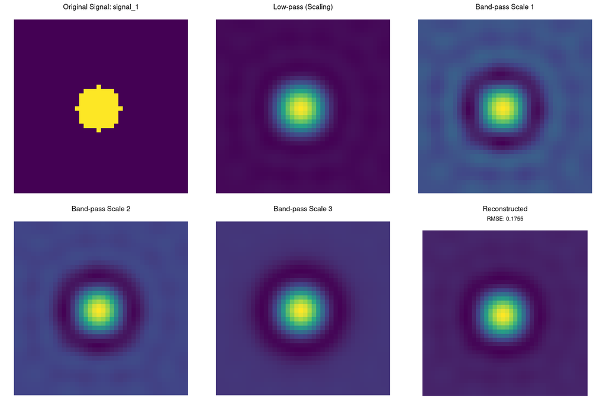

```r
# Plot SGWT decomposition results for signal_1
decomp_plots <- plot_sgwt_decomposition(
  SG = SG,
  signal_name = "signal_1",
  plot_scales = 1:3,     # Show first 3 scales
  ncol = 3
)
```

## Energy Analysis

```r
# Analyze energy distribution across scales for signal_1
energy_analysis <- sgwt_energy_analysis(SG, "signal_1")
print(energy_analysis)
```

```
##       scale    energy energy_ratio scale_value   signal
## 1  low_pass 46.351714   0.75046488  0.37613716 signal_1
## 2 wavelet_1  1.647846   0.02667971  0.37613716 signal_1
## 3 wavelet_2  3.510442   0.05683638  0.18806858 signal_1
## 4 wavelet_3  5.180645   0.08387806  0.09403429 signal_1
## 5 wavelet_4  5.073355   0.08214096  0.04701714 signal_1
```

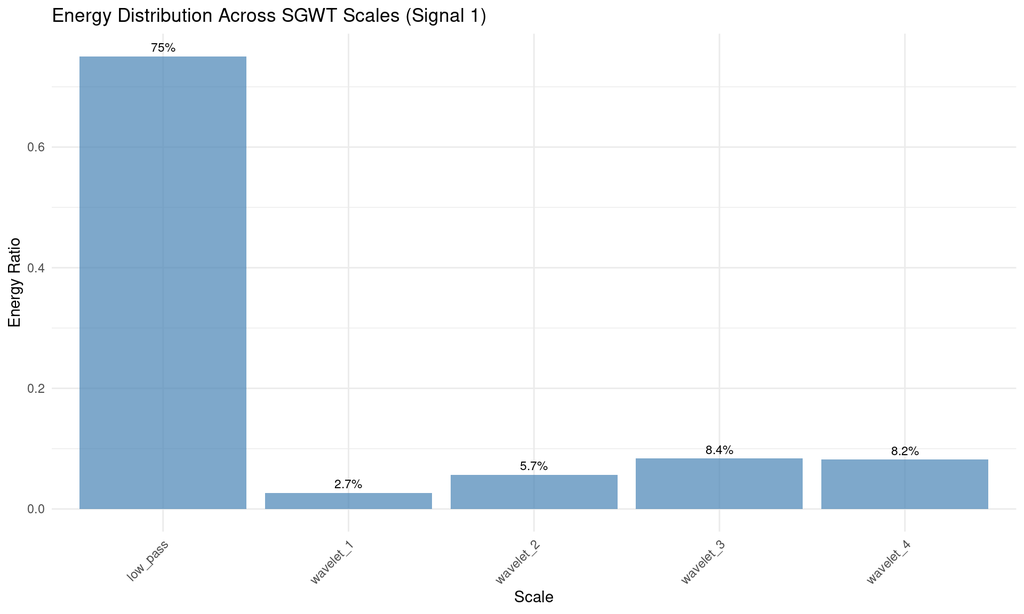

```r
# Create energy distribution plot
energy_plot <- ggplot(energy_analysis, aes(x = scale, y = energy_ratio)) +
  geom_bar(stat = "identity", fill = "steelblue", alpha = 0.7) +
  geom_text(aes(label = paste0(round(energy_ratio * 100, 1), "%")),
            vjust = -0.5, size = 3) +
  labs(title = "Energy Distribution Across SGWT Scales (Signal 1)",
       x = "Scale", y = "Energy Ratio") +
  theme_minimal() +
  theme(axis.text.x = element_text(angle = 45, hjust = 1))

print(energy_plot)
```

# Advanced Features Demonstration

## Different Wavelet Kernels

```r
# Compare different kernel types
kernels <- c("mexican_hat", "meyer", "heat")
kernel_results <- list()

for (kn in kernels) {
  # Initialize with different kernel
  SG_temp <- initSGWT(
    data.in = demo_pattern,
    x_col = "X", y_col = "Y",
    signals = "signal_1",
    J = 3,                    # Reduced for faster computation
    kernel_type = kn
  )

  # Run full workflow
  SG_temp <- runSpecGraph(SG_temp, k = 12, laplacian_type = "normalized", length_eigenvalue = 100,verbose = FALSE)
  SG_temp <- runSGWT(SG_temp, verbose = FALSE)

  kernel_results[[kn]] <- SG_temp
}

# Compare reconstruction errors
comparison_df <- data.frame(
  Kernel = kernels,
  RMSE = sapply(kernel_results, function(x) x$Inverse$signal_1$reconstruction_error),
  stringsAsFactors = FALSE
)

print("Kernel Performance Comparison:")
```

```
## [1] "Kernel Performance Comparison:"
```

```r
print(comparison_df)
```

```
##                  Kernel      RMSE
## mexican_hat mexican_hat 0.1579043
## meyer             meyer 0.1720928
## heat               heat 0.1329538
```

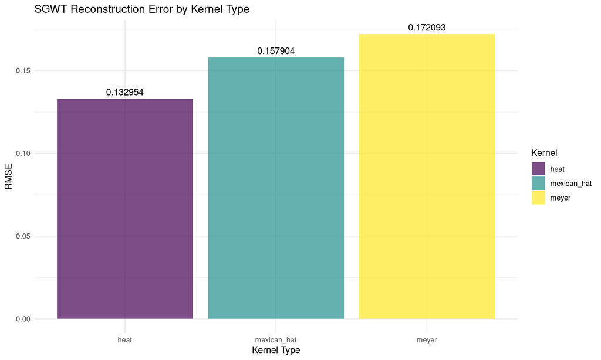

```r
# Plot comparison
ggplot(comparison_df, aes(x = Kernel, y = RMSE, fill = Kernel)) +
  geom_bar(stat = "identity", alpha = 0.7) +
  geom_text(aes(label = round(RMSE, 6)), vjust = -0.5) +
  scale_fill_viridis_d() +
  labs(title = "SGWT Reconstruction Error by Kernel Type",
       x = "Kernel Type", y = "RMSE") +
  theme_minimal()
```

## Step 4: Pattern Similarity Analysis

```r
# Calculate similarity between signal_1 and signal_2 in same object
similarity_within <- runSGCC("signal_1", "signal_2", SG = SG, return_parts = TRUE)

cat("Pattern Similarity Analysis (within same graph):\n")
```

```
## Pattern Similarity Analysis (within same graph):
```

```r
cat(sprintf("Overall similarity: %.4f\n", similarity_within$S))
```

```
## Overall similarity: -0.1200
```

```r
cat(sprintf("Low-frequency similarity: %.4f\n", similarity_within$c_low))
```

```
## Low-frequency similarity: 0.0005
```

```r
cat(sprintf("Non-low-frequency similarity: %.4f\n", similarity_within$c_nonlow))
```

```
## Non-low-frequency similarity: -0.5266
```

```r
cat(sprintf("Energy weights - Low: %.3f, Non-low: %.3f\n",
           similarity_within$w_low, similarity_within$w_NL))
```

```
## Energy weights - Low: 0.771, Non-low: 0.229
```

```r
# Generate a second pattern for cross-comparison
pattern_2 <- simulate_multiscale(
  grid_size = 40,
  n_centers = 1,
  Ra_seq = 7,            # Different inner radius
  Rb_seq = 12,           # Different outer radius
  seed = 456
)[[1]]
```

```
## Generating 1 multiscale patterns...
##
##
## Multiscale simulation completed!
```

```r
# Create second SGWT object
SG2 <- initSGWT(pattern_2, x_col = "X", y_col = "Y", signals = "signal_1",
                J = 4)
SG2 <- runSpecGraph(SG2, k = 12, laplacian_type = "normalized",length_eigenvalue = 100, verbose = FALSE)
SG2 <- runSGWT(SG2, verbose = FALSE)

# Calculate cross-object similarity
similarity_cross <- runSGCC(SG, SG2, return_parts = TRUE)

cat("\nCross-object Pattern Similarity:\n")
```

```
##
## Cross-object Pattern Similarity:
```

```r
cat(sprintf("Overall similarity: %.4f\n", similarity_cross$S))
```

```
## Overall similarity: 0.9153
```

```r
cat(sprintf("Low-frequency similarity: %.4f\n", similarity_cross$c_low))
```

```
## Low-frequency similarity: 0.9355
```

```r
cat(sprintf("Non-low-frequency similarity: %.4f\n", similarity_cross$c_nonlow))
```

```
## Non-low-frequency similarity: 0.8459
```

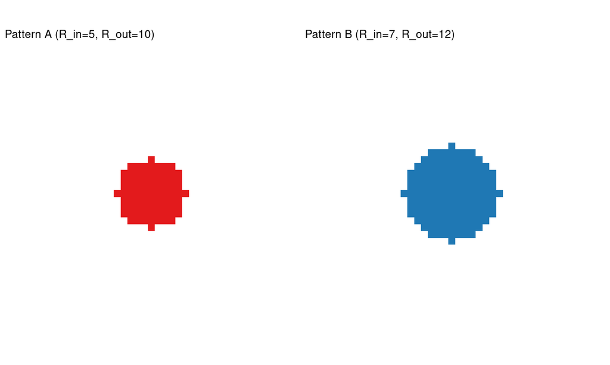

```r
# Visualize both patterns for comparison
p_comp1 <- ggplot(demo_pattern, aes(X, Y, fill = factor(signal_1))) +
  geom_tile() + scale_fill_manual(values = c("0" = "white", "1" = "#e31a1c")) +
  coord_fixed() + theme_void() + theme(legend.position = "none") +
  ggtitle("Pattern A (R_in=5, R_out=10)")

p_comp2 <- ggplot(pattern_2, aes(X, Y, fill = factor(signal_1))) +
  geom_tile() + scale_fill_manual(values = c("0" = "white", "1" = "#1f78b4")) +
  coord_fixed() + theme_void() + theme(legend.position = "none") +
  ggtitle("Pattern B (R_in=7, R_out=12)")

print(p_comp1 + p_comp2)
```

## Low-frequency Only Analysis

```r
# Compare using only low-frequency components
similarity_low <- runSGCC("signal_1", "signal_2", SG = SG, low_only = TRUE, return_parts = TRUE)

cat("Low-frequency Only Similarity Analysis:\n")
```

```
## Low-frequency Only Similarity Analysis:
```

```r
cat(sprintf("Low-frequency similarity: %.4f\n", similarity_low$c_low))
```

```
## Low-frequency similarity: 0.0005
```

```r
cat(sprintf("Overall score (same as low-freq): %.4f\n", similarity_low$S))
```

```
## Overall score (same as low-freq): 0.0005
```

```r
cat("Note: Non-low-frequency components are ignored (c_nonlow = NA)\n")
```

```
## Note: Non-low-frequency components are ignored (c_nonlow = NA)
```

```r
# Compare with full analysis
cat("\nComparison:\n")
```

```
##
## Comparison:
```

```r
cat(sprintf("Full analysis similarity: %.4f\n", similarity_within$S))
```

```
## Full analysis similarity: -0.1200
```

```r
cat(sprintf("Low-only similarity: %.4f\n", similarity_low$S))
```

```
## Low-only similarity: 0.0005
```

```r
cat(sprintf("Difference: %.4f\n", abs(similarity_within$S - similarity_low$S)))
```

```
## Difference: 0.1205
```

## Multiple Signal Analysis

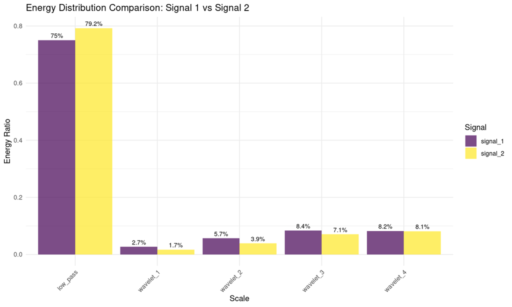

```r
# Analyze energy distribution for both signals
energy_signal1 <- sgwt_energy_analysis(SG, "signal_1")
energy_signal2 <- sgwt_energy_analysis(SG, "signal_2")

# Combine for comparison
energy_comparison <- rbind(energy_signal1, energy_signal2)

# Plot comparison
ggplot(energy_comparison, aes(x = scale, y = energy_ratio, fill = signal)) +
  geom_bar(stat = "identity", position = "dodge", alpha = 0.7) +
  geom_text(aes(label = paste0(round(energy_ratio * 100, 1), "%")),
            position = position_dodge(width = 0.9), vjust = -0.5, size = 3) +
  scale_fill_viridis_d() +
  labs(title = "Energy Distribution Comparison: Signal 1 vs Signal 2",
       x = "Scale", y = "Energy Ratio", fill = "Signal") +
  theme_minimal() +
  theme(axis.text.x = element_text(angle = 45, hjust = 1))
```

# Advanced Workflow Features

## Custom Parameters

```r
# Demonstrate advanced parameter customization
SG_advanced <- initSGWT(
  data.in = demo_pattern,
  x_col = "X", y_col = "Y",
  signals = "signal_1",
  J = 6,                     # More scales for finer analysis
  scaling_factor = 1.5,      # Closer scales
  kernel_type = "heat"       # Heat kernel
)

SG_advanced <- runSpecGraph(SG_advanced, k = 15, laplacian_type = "randomwalk",length_eigenvalue = 30, verbose = FALSE)
SG_advanced <- runSGWT(SG_advanced, verbose = FALSE)

cat("Advanced Parameters Results:\n")
```

```
## Advanced Parameters Results:
```

```r
cat("Number of scales:", length(SG_advanced$Parameters$scales), "\n")
```

```
## Number of scales: 6
```

```r
cat("Scales:", paste(round(SG_advanced$Parameters$scales, 4), collapse = ", "), "\n")
```

```
## Scales: 0.1226, 0.0817, 0.0545, 0.0363, 0.0242, 0.0161
```

```r
cat("Reconstruction error:", round(SG_advanced$Inverse$signal_1$reconstruction_error, 6), "\n")
```

```
## Reconstruction error: 0.256808
```

# Summary

## Key Takeaways

1. **New Object-Oriented Workflow**: Clear separation of initialization, graph building, analysis, and similarity computation
2. **Flexible Input**: Supports custom column naming for coordinates and signals
3. **Multiple Kernels**: Choose from Mexican Hat, Meyer, or Heat kernel families
4. **Comprehensive Similarity**: Energy-normalized weighted similarity with detailed diagnostics
5. **Advanced Analysis**: Low-frequency only analysis, cross-object comparison, multiple signal support

## New Workflow Benefits

```r
# Complete workflow in 4 clear steps:
SG <- initSGWT(data, signals = c("signal1", "signal2"))  # 1. Initialize
SG <- runSpecGraph(SG, k = 12, laplacian_type = "normalized")  # 2. Build graph
SG <- runSGWT(SG)                                        # 3. Run SGWT
similarity <- runSGCC("signal1", "signal2", SG = SG)    # 4. Compare patterns
```

## Parameter Guidelines

- **Small datasets (<200 points)**: k=8-12, J=3-4
- **Medium datasets (200-1000 points)**: k=12-20, J=4-6
- **Large datasets (>1000 points)**: k=15-25, J=5-8

## Next Steps

- Explore your own spatial datasets using the demonstrated workflow
- Experiment with different kernel types and parameters
- Use comprehensive similarity analysis for comparative studies
- Refer to function documentation for detailed parameter specifications

*BioGSP Package - Biological Graph Signal Processing for Spatial Data Analysis*